# 120 Lecture 20

Tim Hagemeister

23 October, 2019

## Quick review: normal dist

Were going to use the normal distro for the rest of our lives in this class, kets do some practice:

Ex) Gibbons have average height 18 inches with SD of 3 inches. gorillas have average height 5.5 feet with a SD of .4 feet. Heights for both species follow a normal distrobution.

1. whats the cahnce that a randomly selected gorilla is at least 6 feet tall? First compute the Z score, then use pnorm

```r
(6-5.5)/.4
```

```
## [1] 1.25
```

- Z scores measure the distance between an observation and the mean, measured in SD. Z- scores give a level playing field. they transform data to a distributino centered at 0 and with SD 1.
- Human feelings based on the 68-95-99.7 rule, not an unusual gorilla. In with most common 95%.

```r
1-pnorm(1.25)
```

```
## [1] 0.1056498
```

2. whats the prob that a rando gibbon is between 15 and 20 inches

```r
pnorm(20, 18, 3) - pnorm(15, 18, 3)
```

```
## [1] 0.5888522
```

## Chapter 5, Section 1: Sampling distributions

Note: Your Reading for Tomorrow is p172.

Recall, Statistical inference is the process of making conclusions about a population based upon a sample from that population. Its what we came here to do! Important Distinctio:mumerical summaries of populations are called “parameters”. They are what we wanna know

- Ex: Population meanm = $\mu$ “mu”

Unfortunate reality: Parameters are unknowable for large populations

Instead we rely on samples. Numerical summaries of samples are called statistics!

- Ex: Sample mean = $\ xbar$ xbar

**Our big goal:** say soemthning smart about $\mu$ based upon xbar. More generally, say something smart about paramters based upon statistics.

- By smart: I mean “Probability”. Given a sample, how likely or unlikely was it?
- To do this, we need probability distros for entire sampel results, not just individuals.
- Were about to make a transition. Stop talking about individuals, and start talking about entire samples.
- its called a “sampling distribution”. Let me show you one on the board

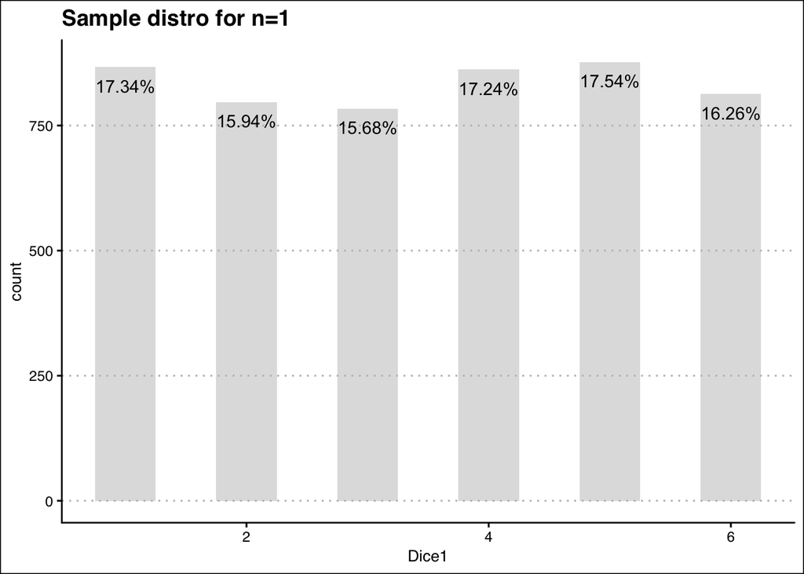

```r
Dice1 <- replicate(5000, mean(sample(1:6, 1, replace=TRUE)))

ggplot() +
  aes(Dice1)+
  geom_histogram(aes(Dice1), binwidth = 0.5 , fill = "gray", alpha = 0.5)+
 geom_text(stat = "count", aes( label = scales::percent(..prop..), vjust = 2))+
  theme_clean()+
  ggtitle("Sample distro for n=1")
```

Were going to compute a sampling distro for **the mean** n=2, the smallest possible.

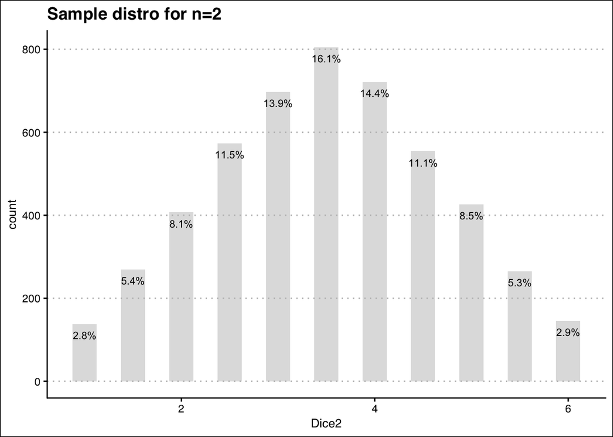

```r
prob <- 1:6
Dice2 <- replicate(5000, mean(sample(1:6, 2, replace=TRUE)))

ggplot() +
  aes(Dice2)+
  geom_histogram(aes(Dice2), binwidth = 0.25, fill = "gray", alpha = 0.5)+
 geom_text(stat = "count", aes( label = scales::percent(..prop..), vjust = 2), size = 3)+
  theme_clean()+
  ggtitle("Sample distro for n=2")
```